# C:\Users\manis\Desktop\Final_Project_DSEM\Dino_Pro

```python
kabaddi_data.shape # to know the total rows and columns in the dataset
```

```
(1262, 25)
```

```python
kabaddi_data.info() # overall info
```

```
<class 'pandas.core.frame.DataFrame'>
RangeIndex: 1262 entries, 0 to 1261
Data columns (total 25 columns):
 #   Column                       Non-Null Count  Dtype
---  ------                       --------------  -----
 0   match_id                     1262 non-null   int64
 1   team_id                      1262 non-null   int64
 2   venue_id                     1262 non-null   int64
 3   team1                        1262 non-null   object
 4   date                         1262 non-null   object
 5   start_time                   1262 non-null   object
 6   team1_score                  1262 non-null   int64
 7   team2                        1262 non-null   object
 8   team2_score                  1262 non-null   int64
 9   all_out                      1262 non-null   int64
```

[output cut: 17 more lines]

```python
kabaddi_data.describe() # to get mean,median,standard deviation, etc
```

|  | match_id | team_id | venue_id | team1_score | team2_score | all_out | declare | extras | raid_bonus_points | raid_touch_points | tackle_capture_points | tackle_capture_bonus_points | empty_raids_count | successful_raids_count | unsuccessful_raids_count | successful_tackles_count | unsuccessful_tackles_count | is_home |
| --- | --- | --- | --- | --- | --- | --- | --- | --- | --- | --- | --- | --- | --- | --- | --- | --- | --- | --- |
| count | 1262.000000 | 1262.000000 | 1262.000000 | 1262.000000 | 1262.000000 | 1262.000000 | 1262.0 | 1262.000000 | 1262.000000 | 1262.000000 | 1262.000000 | 1262.000000 | 1262.000000 | 1262.000000 | 1262.000000 | 1262.000000 | 1262.000000 | 1262.000000 |
| mean | 595.194929 | 9.702853 | 7.600634 | 31.850238 | 31.850238 | 2.362916 | 0.0 | 1.643423 | 3.945325 | 14.248811 | 8.888273 | 0.762282 | 18.424723 | 14.618067 | 9.580824 | 8.809033 | 14.251189 | 0.207607 |
| std | 587.424842 | 10.368682 | 5.700614 | 7.410513 | 7.410513 | 1.935884 | 0.0 | 1.424143 | 2.636778 | 4.850491 | 3.109073 | 1.099594 | 4.566918 | 4.274104 | 3.131439 | 3.091645 | 4.850777 | 0.405755 |
| min | 1.000000 | 1.000000 | 1.000000 | 12.000000 | 12.000000 | 0.000000 | 0.0 | 0.000000 | 0.000000 | 3.000000 | 1.000000 | 0.000000 | 0.000000 | 4.000000 | 1.000000 | 1.000000 | 3.000000 | 0.000000 |
| 25% | 159.250000 | 3.000000 | 4.000000 | 27.000000 | 27.000000 | 0.000000 | 0.0 | 1.000000 | 2.000000 | 11.000000 | 7.000000 | 0.000000 | 15.000000 | 11.250000 | 7.000000 | 7.000000 | 11.000000 | 0.000000 |
| 50% | 362.000000 | 6.000000 | 6.000000 | 31.500000 | 31.500000 | 2.000000 | 0.0 | 1.000000 | 4.000000 | 14.000000 | 9.000000 | 0.000000 | 19.000000 | 14.000000 | 9.000000 | 9.000000 | 14.000000 | 0.000000 |
| 75% | 720.750000 | 8.000000 | 9.750000 | 36.000000 | 36.000000 | 4.000000 | 0.0 | 3.000000 | 5.000000 | 17.000000 | 11.000000 | 1.000000 | 22.000000 | 17.000000 | 12.000000 | 11.000000 | 17.000000 | 0.000000 |
| max | 1800.000000 | 31.000000 | 25.000000 | 69.000000 | 69.000000 | 10.000000 | 0.0 | 7.000000 | 15.000000 | 39.000000 | 20.000000 | 7.000000 | 33.000000 | 31.000000 | 21.000000 | 20.000000 | 39.000000 | 1.000000 |

```python
kabaddi_data.columns # to know the column names
```

```
Index(['match_id', 'team_id', 'venue_id', 'team1', 'date', 'start_time',
       'team1_score', 'team2', 'team2_score', 'all_out', 'declare', 'extras',
       'raid_bonus_points', 'raid_touch_points', 'tackle_capture_points',
       'tackle_capture_bonus_points', 'empty_raids_count',
       'successful_raids_count', 'unsuccessful_raids_count',
       'successful_tackles_count', 'unsuccessful_tackles_count', 'result',
       'series_name', 'stage', 'is_home'],
      dtype='object')
```

```python
kabaddi_data.isnull().sum()
```

```
match_id                         0
team_id                          0
venue_id                         0
team1                            0
date                             0
start_time                       0
team1_score                      0
team2                            0
team2_score                      0
all_out                          0
declare                          0
extras                           0
raid_bonus_points                0
raid_touch_points                0
tackle_capture_points            0
tackle_capture_bonus_points      0
empty_raids_count                0
successful_raids_count           0
unsuccessful_raids_count         0
successful_tackles_count         0
unsuccessful_tackles_count       0
result                           2
series_name                      0
stage                          480
is_home                          0
dtype: int64
```

```python
kabaddi_data.nunique()
```

```
match_id                       631
team_id                         12
venue_id                        19
team1                           13
date                           347
start_time                       5
team1_score                     45
team2                           12
team2_score                     45
all_out                          6
declare                          1
extras                           8
raid_bonus_points               16
raid_touch_points               31
tackle_capture_points           20
tackle_capture_bonus_points      8
empty_raids_count               31
successful_raids_count          27
unsuccessful_raids_count        20
successful_tackles_count        20
unsuccessful_tackles_count      31
result                         572
series_name                      7
stage                            4
is_home                          2
dtype: int64
```

```python
kabaddi_data['team1'].unique()
```

```
array(['Jaipur Pink Panthers', 'U Mumba', 'Bengaluru Bulls',
       'Dabang Delhi K.C.', 'Puneri Paltan', 'Bengal Warriors',
       'Telugu Titans', 'Patna Pirates', 'Dabang Delhi',
       'Haryana Steelers', 'Gujarat Fortunegiants', 'U.P. Yoddha',
       'Tamil Thalaivas'], dtype=object)
```

### According to our research, Puneri Paltan is the team which exist since first season and have not won any seasons and Bengal Warriors has proved itself as a successful team.

#### So lets compare and do analysis on both teams

[figure not shown]

# **“Good team has good Strategies”**- A Good team has good Strategies and techniques which impacted the overall performance of the team and can be used as a sample technique to coach the low score team to Improve their performance!!!

```python
W_Bengal_Matches_Team1 = kabaddi_data[kabaddi_data['team1'] == 'Bengal Warriors']
Puneri_Paltan_Team_1 = kabaddi_data[kabaddi_data['team1'] == 'Puneri Paltan']
```

## Plot 1 describes how many matches have been played by all the teams against Bengal Warriors and Puneri Paltan

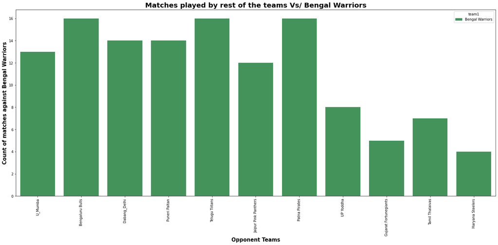

```python
plt.figure(figsize=(25,10))
sns.countplot('team2',hue='team1', data = W_Bengal_Matches_Team1,palette="Greens_d")

plt.xticks(rotation = 90)
plt.xlabel("Opponent Teams", fontsize = '15', fontweight = 'bold')
plt.ylabel("Count of matches against Bengal Warriors",  fontsize = '15', fontweight = 'bold')
plt.title("Matches played by rest of the teams Vs/ Bengal Warriors",  fontsize = '20', fontweight = 'bold')
plt.show()
```

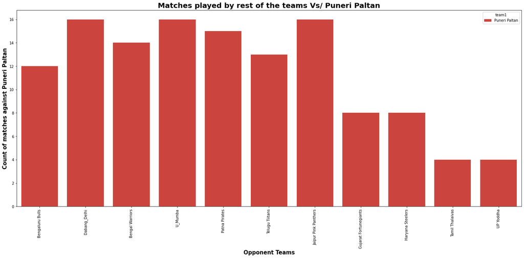

```python
plt.figure(figsize=(25,10))
sns.countplot('team2',hue='team1', data = Puneri_Paltan_Team_1,palette="Reds_d")
plt.xticks(rotation = 90)
plt.xlabel("Opponent Teams", fontsize = '15', fontweight = 'bold')
plt.ylabel("Count of matches against Puneri Paltan",  fontsize = '15', fontweight = 'bold')
plt.title("Matches played by rest of the teams Vs/ Puneri Paltan",  fontsize = '20', fontweight = 'bold')
plt.show()
```

## Plot 2 describes average points scored by opponents against Bengal Warriors and Puneri Paltan respectively

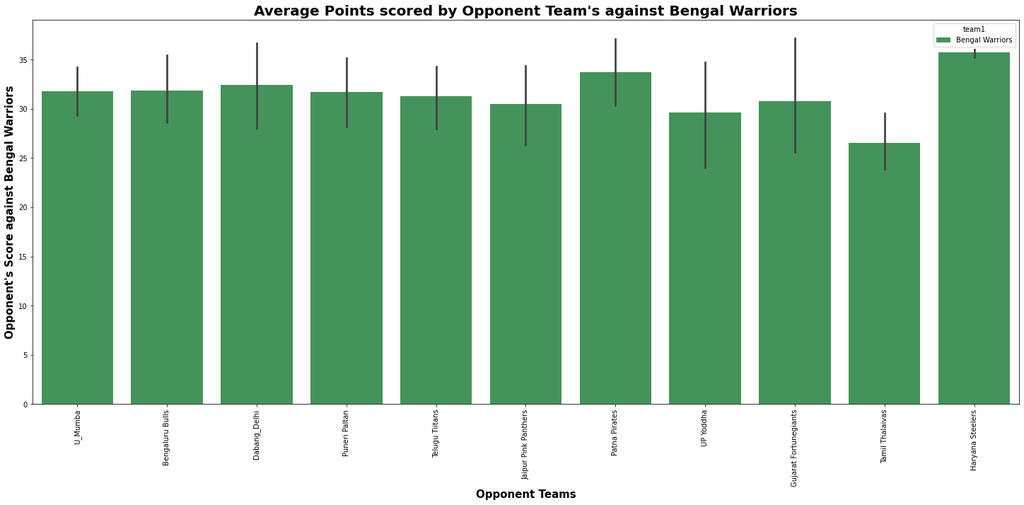

```python
plt.figure(figsize=(25,10))
sns.barplot(x = 'team2', y ='team2_score',hue='team1', data = W_Bengal_Matches_Team1,palette="Greens_d")
plt.xticks(rotation = 90)
plt.xlabel("Opponent Teams",fontsize = '15', fontweight = 'bold')
plt.ylabel("Opponent's Score against Bengal Warriors",fontsize = '15', fontweight = 'bold')
plt.title("Average Points scored by Opponent Team's against Bengal Warriors",  fontsize = '20', fontweight = 'bold')
plt.show()
```

[figure not shown]

```python
plt.figure(figsize=(25,10))
sns.barplot(x = 'team2', y ='team2_score',hue='team1', data = Puneri_Paltan_Team_1,palette="Reds_d")
plt.xticks(rotation = 90)
plt.xlabel("Opponent Teams",fontsize = '15', fontweight = 'bold')
plt.ylabel("Opponent's Score against Bengal Warriors",fontsize = '15', fontweight = 'bold')
plt.title("Average Points scored by Opponent Team's against Bengal Warriors",  fontsize = '20', fontweight = 'bold')
plt.show()
```

## Plot 3 describes Bengal Warriors and Puneri Paltan's scores and the count of how many times they have scored those scores

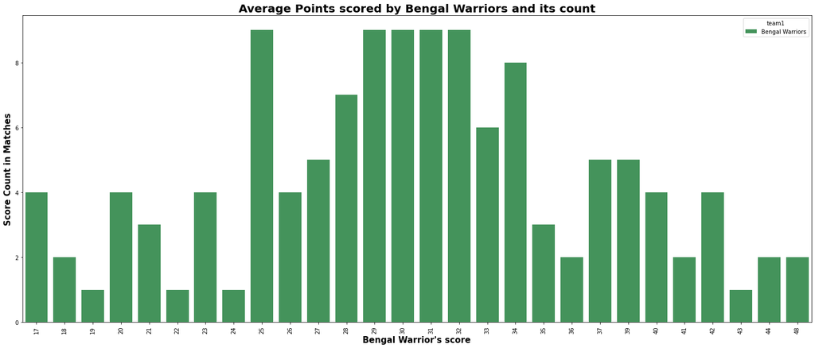

```python
plt.figure(figsize=(25,10))
sns.countplot('team1_score',hue='team1', data = W_Bengal_Matches_Team1, palette="Greens_d")
plt.xticks(rotation = 90)
plt.xlabel("Bengal Warrior's score", fontsize = '15', fontweight = 'bold')
plt.ylabel('Score Count in Matches', fontsize = '15', fontweight = 'bold')
plt.title("Average Points scored by Bengal Warriors and its count",  fontsize = '20', fontweight = 'bold')
#plt.show()
```

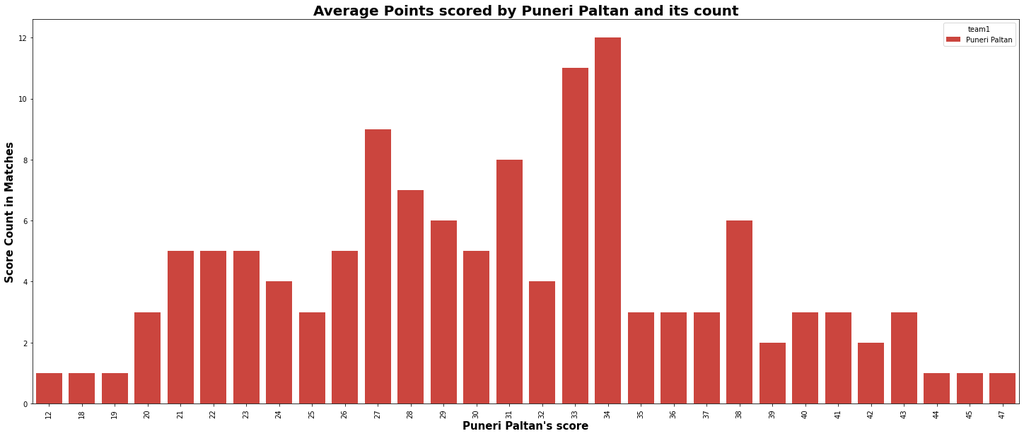

```python
plt.figure(figsize=(25,10))
sns.countplot('team1_score',hue='team1', data = Puneri_Paltan_Team_1, palette="Reds_d")
plt.xticks(rotation = 90)
plt.xlabel("Puneri Paltan's score",fontsize = '15', fontweight = 'bold')
plt.ylabel('Score Count in Matches',fontsize = '15', fontweight = 'bold')
plt.title("Average Points scored by Puneri Paltan and its count",  fontsize = '20', fontweight = 'bold')
plt.show()
```

```python
conditions=[W_Bengal_Matches_Team1['team1_score']>W_Bengal_Matches_Team1['team2_score'],
            W_Bengal_Matches_Team1['team1_score']<W_Bengal_Matches_Team1['team2_score']]
```

```python
choices = ['Won', 'Lost']
```

```python
W_Bengal_Matches_Team1['Final_Result'] = np.select(conditions, choices, default='Draw')
```

```python
conditions1=[Puneri_Paltan_Team_1['team1_score']>Puneri_Paltan_Team_1['team2_score'],
            Puneri_Paltan_Team_1['team1_score']<Puneri_Paltan_Team_1['team2_score']]
```

```python
choices1 = ['Won', 'Lost']
```

```python
Puneri_Paltan_Team_1['Final_Result'] = np.select(conditions1, choices1, default='Draw')
```

## Plot 4 describes analysis of the number of matches won or lost by Bengal Warriors and Puneri Paltan

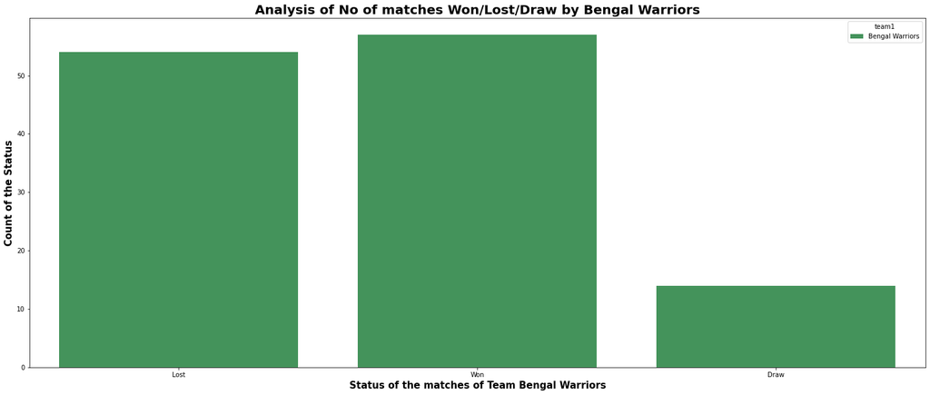

```python
plt.figure(figsize=(25,10))
sns.countplot(x = 'Final_Result',hue='team1', data = W_Bengal_Matches_Team1,palette="Greens_d")
# plt.xticks(rotation = 90)
plt.xlabel("Status of the matches of Team Bengal Warriors", fontsize = '15', fontweight = 'bold')
plt.ylabel("Count of the Status",  fontsize = '15', fontweight = 'bold')
plt.title("Analysis of No of matches Won/Lost/Draw by Bengal Warriors",  fontsize = '20', fontweight = 'bold')

plt.show()
```

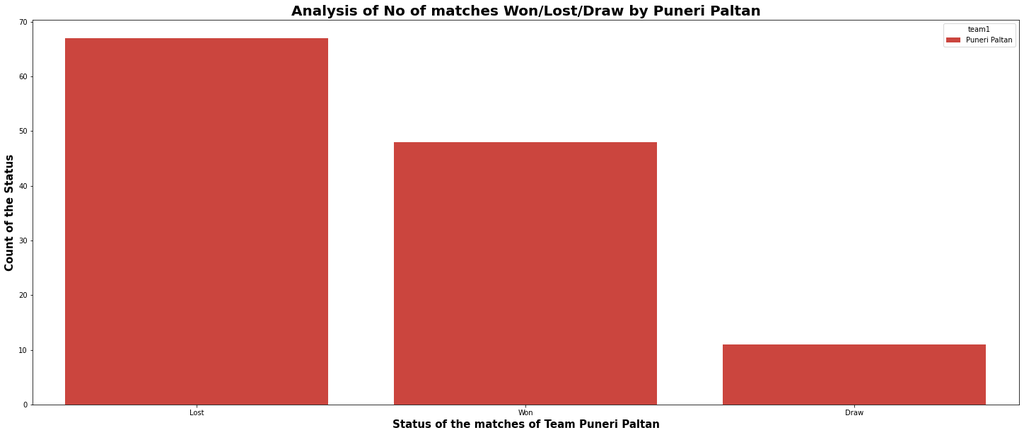

```python
plt.figure(figsize=(25,10))
sns.countplot(x = 'Final_Result',hue='team1', data = Puneri_Paltan_Team_1, palette="Reds_d")
# plt.xticks(rotation = 90)
plt.xlabel("Status of the matches of Team Puneri Paltan", fontsize = '15', fontweight = 'bold')
plt.ylabel("Count of the Status",  fontsize = '15', fontweight = 'bold')
plt.title("Analysis of No of matches Won/Lost/Draw by Puneri Paltan",  fontsize = '20', fontweight = 'bold')

plt.show()
```

## As per our analysis too it is proved that, Bengal Warriors has won more matches than Puneri Paltan

#### Let us analyze the Bengal Warrior's and Puneri Paltan's players performance

```python
players_data = pd.read_csv('C:/Users/manis/Desktop/Final_Project_DSEM/PlayerData.csv')
```

```python
players_data.Team.unique()
```

```
array(['Dabang Delhi K.C.', 'Bengaluru Bulls', 'Patna Pirates',
       'Bengal Warriors', 'Telugu Titans', 'Haryana Steelers',
       'Puneri Paltan', 'Tamil Thalaivas', 'U Mumba', 'U.P. Yoddha',
       'Gujarat Fortunegiants', 'Jaipur Pink Panthers'], dtype=object)
```

[figure not shown]

```python
W_Bengal = players_data[players_data.Team =='Bengal Warriors']
team_bengal = W_Bengal
team_bengal.head()
```

|  | Unnamed: 0 | Name | Position | Born | Team | Height | Nationality | Weight | Match Played | Points | ... | Super_raids | Super_10s | Tackles | Successful Tackles | Unsuccessful Tackles | Successful Tackles Per Match | Tackle Bonus Points | Tackle Success Rate | Super_tackles | High 5s |
| --- | --- | --- | --- | --- | --- | --- | --- | --- | --- | --- | --- | --- | --- | --- | --- | --- | --- | --- | --- | --- | --- |
| 3 | 0 | Maninder Singh | Raider | 1-Jan-90 | Bengal Warriors | 6 ft | India | 76 kg | 20 | 205 | ... | 6 | 10 | 7 | 0 | 7 | 0.00 | 0 | 0.00 | 0 | 0 |
| 6 | 6 | Naveen Narwal | Defender, right cover | 1-Jan-70 | Bengal Warriors | - | India | - | 3 | 1 | ... | 0 | 0 | 8 | 1 | 7 | 0.33 | 0 | 12.50 | 0 | 0 |
| 7 | 7 | Amit | Defender, right corner | 12-Dec-98 | Bengal Warriors | 5 ft 5 in | India | 74 kg | 4 | 0 | ... | 0 | 0 | 1 | 0 | 1 | 0.00 | 0 | 0.00 | 0 | 0 |
| 8 | 8 | Baldev Singh | Defender, right corner | 27-May-93 | Bengal Warriors | 5 ft 10 in | India | 74 kg | 20 | 59 | ... | 0 | 0 | 105 | 54 | 51 | 2.70 | 0 | 56.19 | 5 | 6 |
| 9 | 9 | Jeeva Kumar | Defender, right and left cover | 1-Jun-81 | Bengal Warriors | 5 ft 5 in | India | 72 kg | 19 | 32 | ... | 0 | 0 | 86 | 31 | 55 | 1.63 | 0 | 37.20 | 1 | 0 |

5 rows × 30 columns

[figure not shown]

```python
P_Pune = players_data[players_data.Team =='Puneri Paltan']
team_pune = P_Pune
team_pune.head()
```

|  | Unnamed: 0 | Name | Position | Born | Team | Height | Nationality | Weight | Match Played | Points | ... | Super_raids | Super_10s | Tackles | Successful Tackles | Unsuccessful Tackles | Successful Tackles Per Match | Tackle Bonus Points | Tackle Success Rate | Super_tackles | High 5s |
| --- | --- | --- | --- | --- | --- | --- | --- | --- | --- | --- | --- | --- | --- | --- | --- | --- | --- | --- | --- | --- | --- |
| 20 | 132 | Manjeet | Raider | 30-Oct-96 | Puneri Paltan | - | India | - | 20 | 131 | ... | 2 | 2 | 57 | 26 | 31 | 1.30 | 0 | 47.36 | 1 | 0 |
| 24 | 134 | Pankaj Mohite | Raider | 1-Jan-70 | Puneri Paltan | - | India | - | 16 | 113 | ... | 4 | 3 | 15 | 3 | 12 | 0.18 | 0 | 20.00 | 0 | 0 |
| 60 | 133 | Nitin Tomar | Raider | 30-Apr-95 | Puneri Paltan | 5 ft 9 in | India | - | 13 | 60 | ... | 0 | 1 | 25 | 5 | 20 | 0.38 | 0 | 24.00 | 1 | 0 |
| 97 | 129 | Amit Kumar | Raider | 27-Dec-99 | Puneri Paltan | 5 ft 7 in | India | 70 kg | 13 | 37 | ... | 0 | 0 | 41 | 19 | 22 | 1.46 | 0 | 48.78 | 1 | 0 |
| 112 | 135 | Pawan Kumar | Raider | 11-Oct-94 | Puneri Paltan | 6 ft 1 in | India | 82 kg | 6 | 25 | ... | 0 | 1 | 2 | 0 | 2 | 0.00 | 0 | 0.00 | 0 | 0 |

5 rows × 30 columns

### Plot 5 describes the top players performance and the points they scored

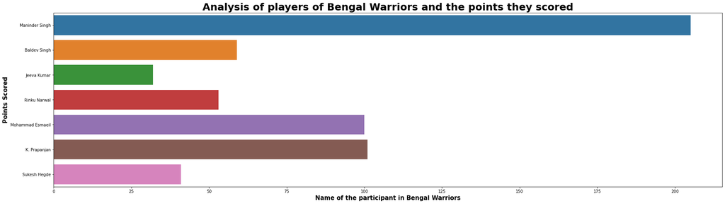

```python
a=team_bengal[team_bengal.Points > 10]
plt.figure(figsize=(30,8))
plt.xticks=180
sns.barplot(y='Name',x='Points',data=a)
plt.xlabel("Name of the participant in Bengal Warriors", fontsize = '15', fontweight = 'bold')
plt.ylabel("Points Scored",  fontsize = '15', fontweight = 'bold')
plt.title("Analysis of players of Bengal Warriors and the points they scored",  fontsize = '25', fontweight = 'bold')
```

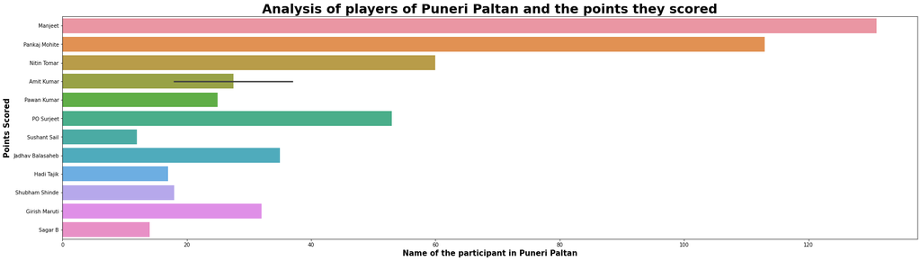

```python
b=team_pune[team_pune.Points > 10]
plt.figure(figsize=(30,8))
plt.xticks=180
sns.barplot(y='Name',x='Points',data=b)
plt.xlabel("Name of the participant in Puneri Paltan", fontsize = '15', fontweight = 'bold')
plt.ylabel("Points Scored",  fontsize = '15', fontweight = 'bold')
plt.title("Analysis of players of Puneri Paltan and the points they scored",  fontsize = '25', fontweight = 'bold')
```

### Plot 6 describes points scored by players in different positions

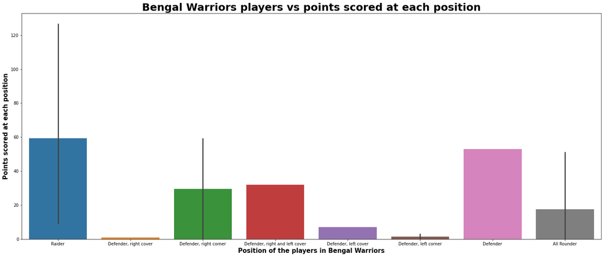

```python
plt.figure(figsize=(25,10))
sns.barplot(x=team_bengal.Position , y= team_bengal.Points,data=team_bengal)
plt.xlabel("Position of the players in Bengal Warriors",  fontsize = '15',fontweight = 'bold')
plt.ylabel("Points scored at each position", fontsize = '15', fontweight = 'bold')
plt.title("Bengal Warriors players vs points scored at each position", fontsize = '25', fontweight = 'bold')
```

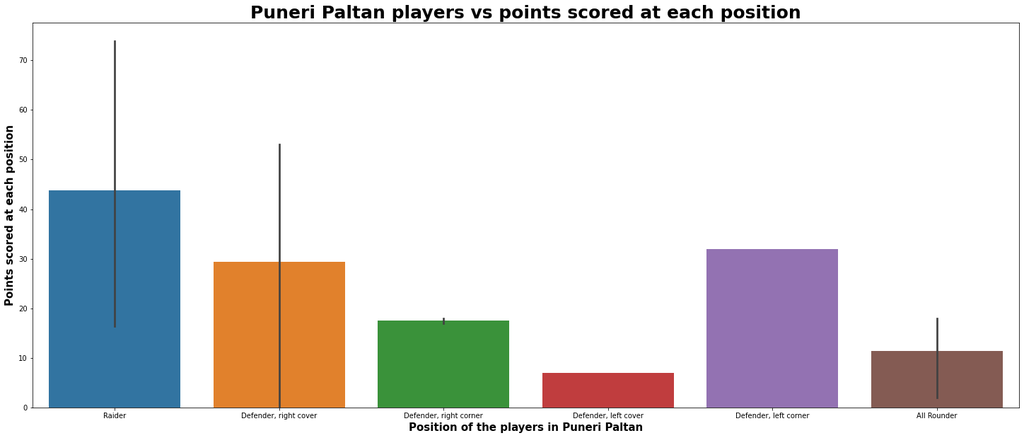

```python
plt.figure(figsize=(25,10))
sns.barplot(x=team_pune.Position , y= team_pune.Points,data=team_pune)
plt.xlabel("Position of the players in Puneri Paltan",  fontsize = '15',fontweight = 'bold')
plt.ylabel("Points scored at each position", fontsize = '15', fontweight = 'bold')
plt.title("Puneri Paltan players vs points scored at each position", fontsize = '25', fontweight = 'bold')
```

##### But in Puneri Platan, the contribution to overall points is less and also its in fewer positions

### Plot 7 describes successful raid percentage vs the points

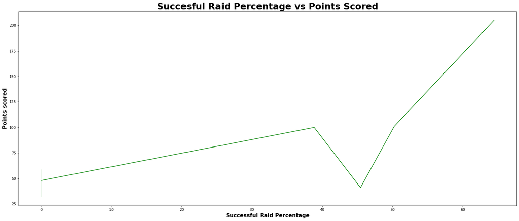

```python
plt.figure(figsize=(25,10))
sns.lineplot(x=a.Successful_Raid_Per,y=a.Points,data=a, color = 'green')


plt.xlabel("Successful Raid Percentage",  fontsize = '15',fontweight = 'bold')
plt.ylabel("Points scored", fontsize = '15', fontweight = 'bold')
plt.title("Succesful Raid Percentage vs Points Scored", fontsize = '25', fontweight = 'bold')
```

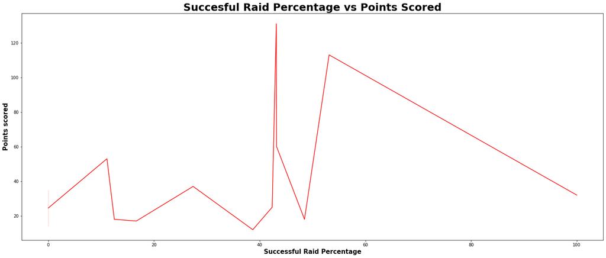

```python
plt.figure(figsize=(25,10))
sns.lineplot(x=b.Successful_Raid_Per,y=b.Points,data=b, color = 'red')


plt.xlabel("Successful Raid Percentage",  fontsize = '15',fontweight = 'bold')
plt.ylabel("Points scored", fontsize = '15', fontweight = 'bold')
plt.title("Succesful Raid Percentage vs Points Scored", fontsize = '25', fontweight = 'bold')
```

### Plot 8 describes how many players got points by Super Tackles

###### Tackling a raider and stopping him from escaping to the midline amounts to one point in kabaddi, however, if a team is reduced to three or fewer players, executing the same earns them an extra point, therefore a total of two points for a single tackle. Such a tackle is known as a ‘Super Tackle’.

### Super Tackles by Bengal Warriors

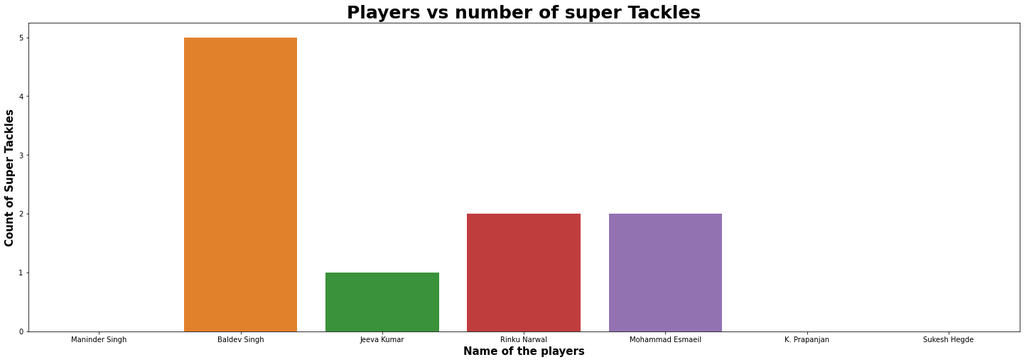

```python
plt.figure(figsize=(25,10))
sns.barplot(x=a.Name , y= a.Super_tackles,data=a)


plt.xlabel("Name of the players",  fontsize = '15',fontweight = 'bold')
plt.ylabel("Count of Super Tackles", fontsize = '15', fontweight = 'bold')
plt.title("Players vs number of super Tackles", fontsize = '25', fontweight = 'bold')
```

### Super Tackles by Puneri Paltan

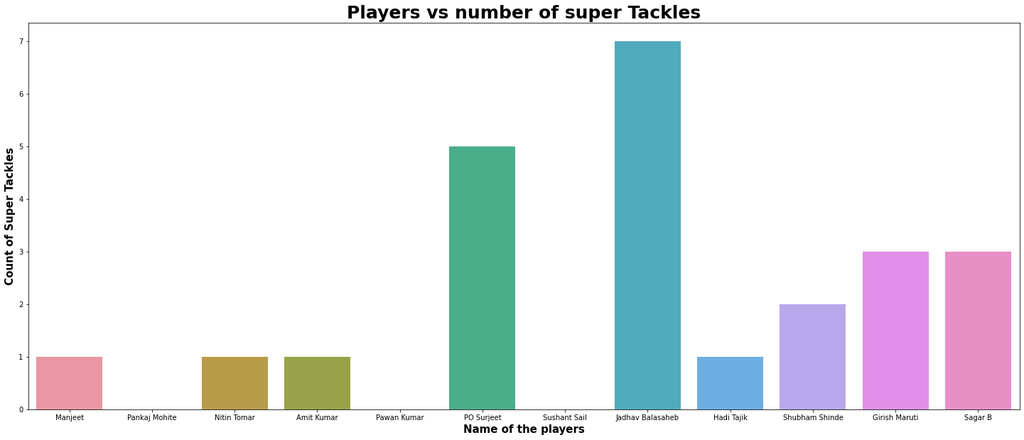

```python
plt.figure(figsize=(25,10))
sns.barplot(x=b.Name , y= b.Super_tackles,data=b)

plt.xlabel("Name of the players",  fontsize = '15',fontweight = 'bold')
plt.ylabel("Count of Super Tackles", fontsize = '15', fontweight = 'bold')
plt.title("Players vs number of super Tackles", fontsize = '25', fontweight = 'bold')
```

#### Puneri Paltan shows good results in Super Tackles which is an amazing attribute they should keep it growing, on the other hand , Bengal Warriors cna work on this to be more successful.

### Plot 9 describes how many players got points by Super 10's

# Super 10s by Bengal Warriors

**A Super 10** is achieved when a raider scores 10 or more raid points in a single game. The points could be either bonus or touch points but not points awarded to the overall team, such as technical points. A raider needs to be **agile and quick thinker** to be aware of the opportunities available to pick up points by exploiting the chinks in the opposition defence. He also needs to have **multiple attacking options** at his disposal if he hopes to outfox the opposition defence repeatedly and return with 10 or more raid points.

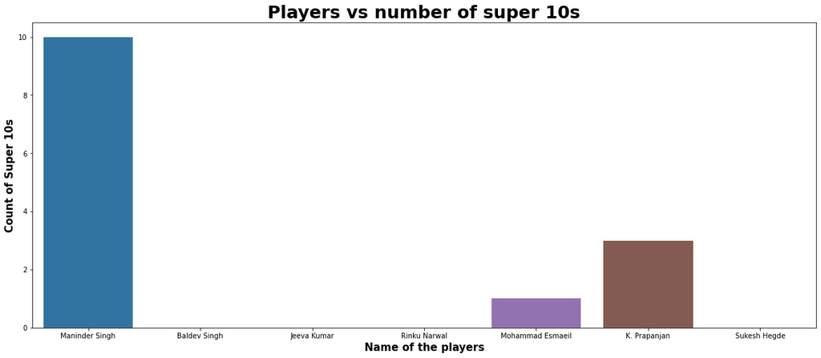

```python
plt.figure(figsize=(20,8))
sns.barplot(x=a.Name, y= a.Super_10s,data=a)

plt.xlabel("Name of the players",  fontsize = '15',fontweight = 'bold')
plt.ylabel("Count of Super 10s", fontsize = '15', fontweight = 'bold')
plt.title("Players vs number of super 10s", fontsize = '25', fontweight = 'bold')
```